# Reproducible Research Assignment 1

# 1. Set Up

Setting the Working Directory for the Assignment

```r
getwd()
```

```
## [1] "/Users/Andreas/Desktop/Reproducible Research/Assignment 1/Activity Monitoring Data "
```

```r
setwd("~/Desktop/Reproducible Research/Assignment 1/Activity Monitoring Data ")
```

# 2. Loading and preprocessing the data

```r
activity <- read.csv("~/Desktop/Reproducible Research/Assignment 1/Activity Monitoring Data /activity.csv")
```

# 3. Exploring and analyzing the data

Here we will xplore the inital data set a bit further

## 3.1 Summary statistics for the data set.

Areas I was interested in were: 1.Head of the Data 2.Dimensions 3.Structure 4.Names of Variables 5.Summary Statistics

```r
head(activity)
```

```
##   steps       date interval
## 1    NA 2012-10-01        0
## 2    NA 2012-10-01        5
## 3    NA 2012-10-01       10
## 4    NA 2012-10-01       15
## 5    NA 2012-10-01       20
## 6    NA 2012-10-01       25
```

```r
dim(activity)
```

```
## [1] 17568     3
```

```r
str(activity)
```

```
## 'data.frame':    17568 obs. of  3 variables:
##  $ steps   : int  NA NA NA NA NA NA NA NA NA NA ...
##  $ date    : Factor w/ 61 levels "2012-10-01","2012-10-02",..: 1 1 1 1 1 1 1 1 1 1 ...
##  $ interval: int  0 5 10 15 20 25 30 35 40 45 ...
```

```r
names(activity)
```

```
## [1] "steps"    "date"     "interval"
```

```r
summary(activity)
```

```
##      steps                date          interval
##  Min.   :  0.00   2012-10-01:  288   Min.   :   0.0
##  1st Qu.:  0.00   2012-10-02:  288   1st Qu.: 588.8
##  Median :  0.00   2012-10-03:  288   Median :1177.5
##  Mean   : 37.38   2012-10-04:  288   Mean   :1177.5
##  3rd Qu.: 12.00   2012-10-05:  288   3rd Qu.:1766.2
##  Max.   :806.00   2012-10-06:  288   Max.   :2355.0
##  NA's   :2304     (Other)   :15840
```

Here we can see the that the total number of NA’s in the activity dataset is 2304 WE will have to convert the data to a date class before we can continue

```r
activity$date <- as.Date(activity$date)
str(activity)
```

```
## 'data.frame':    17568 obs. of  3 variables:
##  $ steps   : int  NA NA NA NA NA NA NA NA NA NA ...
##  $ date    : Date, format: "2012-10-01" "2012-10-01" ...
##  $ interval: int  0 5 10 15 20 25 30 35 40 45 ...
```

## 3.2 Examining specific areas of the data set:

In this part, we will examine the following aspects:

### 3.2.1 Total number of steps taken per day histogram.

First we will create a dataset that exlcudes any NA values

```r
activity_rm.na <- activity[which(!is.na(activity$steps)), ]
```

Next we need to create to aggregate the data per day for plotting the histogram

```r
daily <- tapply(activity_rm.na$steps, activity_rm.na$date, sum)
```

The total number of days depicted as a histogram.

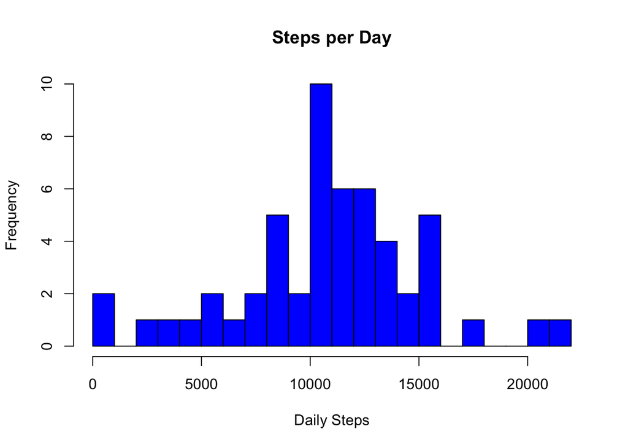

```r
par(mfrow = c(1, 1))
hist(daily, 20, xlab = "Daily Steps", ylab = "Frequency", main = "Steps per Day", col = "blue")
```

### 3.2.2 Calculation of the mean and median of the total number of steps taken per day.

```r
mean(daily)
```

```
## [1] 10766.19
```

```r
median(daily)
```

```
## [1] 10765
```

### 3.2.3 Depiction of the daily activitiy pattern

Here the average daily activity pattern needs to be depicted.

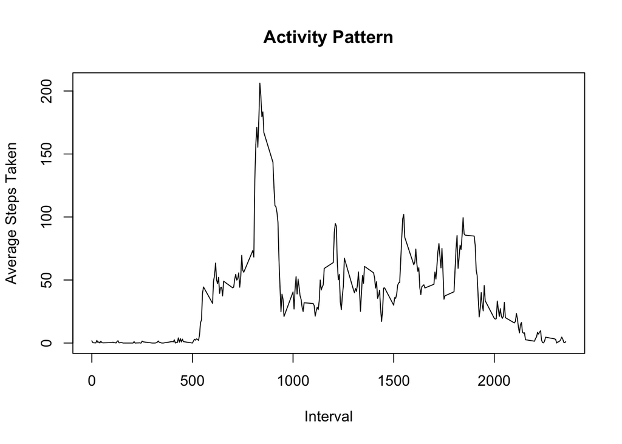

```r
mean_activity <- tapply(activity_rm.na$steps, activity_rm.na$interval, mean)
plot(names(mean_activity), mean_activity, type = "l", xlab = "Interval", ylab = "Average Steps Taken", main = "Activity Pattern")
```

finding out the interval with the maximum number of steps:

```r
mean_activity[mean_activity==max(mean_activity)]
```

```
##      835
## 206.1698
```

## 4. Taking into account NA values and creation of a new data set that does not contain NAs

As we have previously discovered, the presence of NAs in the data set introduces some negative bias to the data set. From our previous analysis, we know that the variable activity has 2304 NA values. Lets quickly reestablish that:

```r
summary(activity$steps)
```

```
##    Min. 1st Qu.  Median    Mean 3rd Qu.    Max.    NA's
##    0.00    0.00    0.00   37.38   12.00  806.00    2304
```

Now that we have reestablished that this is the case, let use the mean for the respective interval to deal with those values.

```r
activity_new <- activity
activity_new[which(is.na(activity_new$steps)), 1] <- mean_activity[as.character(activity_new[which(is.na(activity_new$steps)), 3])]
sum(is.na(activity_new))
```

```
## [1] 0
```

As we can see, we have successfully removed any NA values that were present in our data set.

Creating the Histogram:

```r
daily_new <- tapply(activity_new$steps, activity_new$date,sum)
```

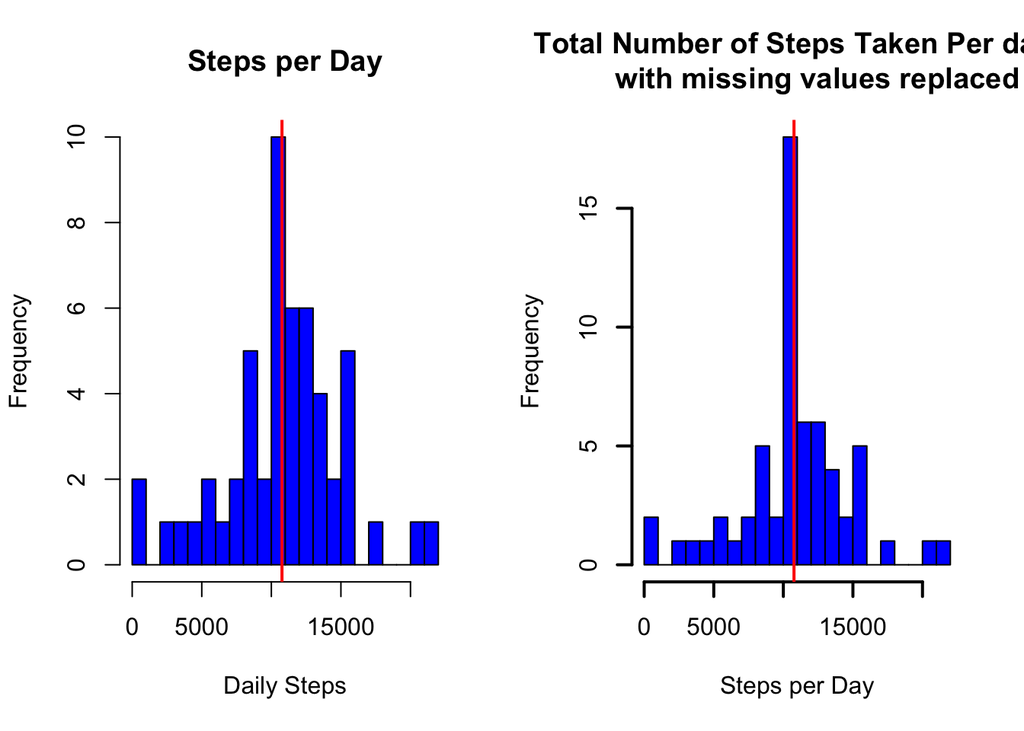

```r
par(mfrow = c(1, 2))
hist(daily, 20, xlab = "Daily Steps", ylab = "Frequency", main = "Steps per Day", col = 4)
abline(v = median(daily), col = 2, lwd = 2)
hist(daily_new, 20, xlab = "Steps per Day", ylab = "Frequency", main = "Total Number of Steps Taken Per day
     with missing values replaced", col = 4, lwd = 2)
abline(v = median(daily_new), col = 2, lwd = 2)
```

Having dealt with the NA values, allows us to compute the new summary statistics also being able to look at how these changed after accounting for the missing values (only minor differnce)

```r
summary(daily)
```

```
##    Min. 1st Qu.  Median    Mean 3rd Qu.    Max.
##      41    8841   10760   10770   13290   21190
```

```r
summary(daily_new)
```

```
##    Min. 1st Qu.  Median    Mean 3rd Qu.    Max.
##      41    9819   10770   10770   12810   21190
```

```r
summary(daily)-summary(daily_new)
```

```
##    Min. 1st Qu.  Median    Mean 3rd Qu.    Max.
##       0    -978     -10       0     480       0
```

## 5. Examining the differences in activity patterns between week days and week ends.

In this part we will examine if there are any differences in the activity patterns for week days and week ends. As such we will do the following:

```r
activity_new$wd<-weekdays(activity_new$date)
activity_new$fwd<- as.factor(c("weekend", "weekday"))
activity_new[activity_new$wd == "Sunday" | activity_new$wd == "Saturday" ,5]<- factor("weekend")
activity_new[!(activity_new$wd == "Sunday" | activity_new$wd == "Saturday"),5 ]<- factor("weekday")
```

Creating the Plot

[figure not shown]

```r
activity_new_we <- subset(activity_new, fwd == "weekend")
activity_new_wd <- subset(activity_new, fwd == "weekday")
dailyactivity_we<-tapply(activity_new_we$steps, activity_new_we$interval, mean)
dailyactivity_wd<-tapply(activity_new_wd$steps, activity_new_wd$interval, mean)
par(mfrow=c(1,2))
plot(y = dailyactivity_wd, x = names(dailyactivity_wd), type = "l", xlab = "5-Minute Interval",
     main = "Daily Activity Pattern on Weekdays", ylab = "Average number of steps",
     ylim =c(0, 250))
abline(v = median(dailyactivity_wd), col = 2, lwd = 2)
plot(y = dailyactivity_we, x = names(dailyactivity_we), type = "l", xlab = "5-Minute Interval",
     main = "Daily Activity Pattern on Weekends", ylab = "Average number of steps",
     ylim =c(0, 250))
abline(v = median(dailyactivity_we), col = 2, lwd = 2)
```